# Ad hoc methods and `mice`

Gerko Vink and Stef van Buuren

Vignette 1 of 6

This is the first vignette in a series of six. It will give you an introduction to the `R`-package `mice`, an open-source tool for flexible imputation of incomplete data, developed by Stef van Buuren and Karin Groothuis-Oudshoorn (2011). Over the last decade, `mice` has become an important piece of imputation software, offering a very flexible environment for dealing with incomplete data. Moreover, the ability to integrate `mice` with other packages in `R`, and vice versa, offers many options for applied researchers.

The aim of this introduction is to enhance your understanding of multiple imputation, in general. You will learn how to multiply impute simple datasets and how to obtain the imputed data for further analysis. The main objective is to increase your knowledge and understanding on applications of multiple imputation.

No previous experience with `R` is required.

##### Working with mice

**1. Open `R` and load the packages `mice` and `lattice`**

```r
require(mice)
require(lattice)
set.seed(123)
```

If `mice` is not yet installed, run:

```r
install.packages("mice")
```

**2. Inspect the incomplete data**

The `mice` package contains several datasets. Once the package is loaded, these datasets can be used. Have a look at the `nhanes` dataset (Schafer, 1997, Table 6.14) by typing

```r
nhanes
```

```
##    age  bmi hyp chl
## 1    1   NA  NA  NA
## 2    2 22.7   1 187
## 3    1   NA   1 187
## 4    3   NA  NA  NA
## 5    1 20.4   1 113
## 6    3   NA  NA 184
## 7    1 22.5   1 118
## 8    1 30.1   1 187
## 9    2 22.0   1 238
## 10   2   NA  NA  NA
## 11   1   NA  NA  NA
## 12   2   NA  NA  NA
## 13   3 21.7   1 206
## 14   2 28.7   2 204
## 15   1 29.6   1  NA
## 16   1   NA  NA  NA
## 17   3 27.2   2 284
## 18   2 26.3   2 199
## 19   1 35.3   1 218
## 20   3 25.5   2  NA
## 21   1   NA  NA  NA
## 22   1 33.2   1 229
## 23   1 27.5   1 131
## 24   3 24.9   1  NA
## 25   2 27.4   1 186
```

The `nhanes` dataset is a small data set with non-monotone missing values. It contains 25 observations on four variables: *age group*, *body mass index*, *hypertension* and *cholesterol (mg/dL)*.

To learn more about the data, use one of the two following help commands:

```r
help(nhanes)
?nhanes
```

**3. Get an overview of the data by the `summary()` command:**

```r
summary(nhanes)
```

```
##       age            bmi             hyp             chl
##  Min.   :1.00   Min.   :20.40   Min.   :1.000   Min.   :113.0
##  1st Qu.:1.00   1st Qu.:22.65   1st Qu.:1.000   1st Qu.:185.0
##  Median :2.00   Median :26.75   Median :1.000   Median :187.0
##  Mean   :1.76   Mean   :26.56   Mean   :1.235   Mean   :191.4
##  3rd Qu.:2.00   3rd Qu.:28.93   3rd Qu.:1.000   3rd Qu.:212.0
##  Max.   :3.00   Max.   :35.30   Max.   :2.000   Max.   :284.0
##                 NA's   :9       NA's   :8       NA's   :10
```

**4. Inspect the missing data pattern**

Check the missingness pattern for the `nhanes` dataset

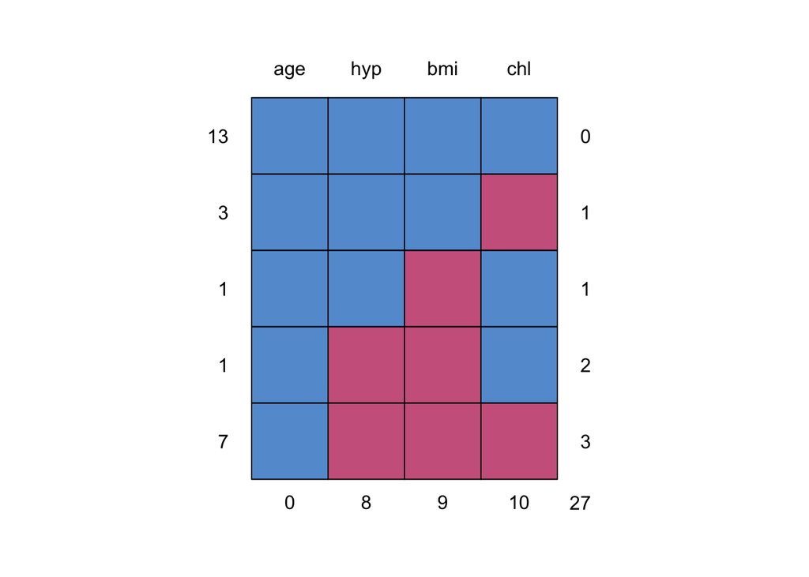

```
##    age hyp bmi chl
## 13   1   1   1   1  0
## 3    1   1   1   0  1
## 1    1   1   0   1  1
## 1    1   0   0   1  2
## 7    1   0   0   0  3
##      0   8   9  10 27
```

```r
md.pattern(nhanes)
```

The missingness pattern shows that there are 27 missing values in total: 10 for `chl` , 9 for `bmi` and 8 for `hyp`. Moreover, there are thirteen completely observed rows, four rows with 1 missing, one row with 2 missings and seven rows with 3 missings. Looking at the missing data pattern is always useful (but may be difficult for datasets with many variables). It can give you an indication on how much information is missing and how the missingness is distributed.

##### Ad Hoc imputation methods

**5. Form a regression model where `age` is predicted from `bmi`.**

```r
fit <- with(nhanes, lm(age ~ bmi))
summary(fit)
```

```
##
## Call:
## lm(formula = age ~ bmi)
##
## Residuals:
##     Min      1Q  Median      3Q     Max
## -1.2660 -0.5614 -0.1225  0.4660  1.2344
##
## Coefficients:
##             Estimate Std. Error t value Pr(>|t|)
## (Intercept)  3.76718    1.31945   2.855   0.0127 *
## bmi         -0.07359    0.04910  -1.499   0.1561
## ---
## Signif. codes:  0 '***' 0.001 '**' 0.01 '*' 0.05 '.' 0.1 ' ' 1
##
## Residual standard error: 0.8015 on 14 degrees of freedom
##   (9 observations deleted due to missingness)
## Multiple R-squared:  0.1383, Adjusted R-squared:  0.07672
## F-statistic: 2.246 on 1 and 14 DF,  p-value: 0.1561
```

**6. Impute the missing data in the `nhanes` dataset with mean imputation.**

```r
imp <- mice(nhanes, method = "mean", m = 1, maxit = 1)
```

The imputations are now done. As you can see, the algorithm ran for 1 iteration (`maxit = 1`) and presented us with only 1 imputation (`m = 1`) for each missing datum. This is correct, as substituting each missing data multiple times with the observed data mean would not make any sense (the inference would be equal, no matter which imputed dataset we would analyze). Likewise, more iterations would be computationally inefficient as the *observed* data mean does not change based on our imputations. We named the imputed object `imp` following the convention used in `mice`, but if you wish you can name it anything you’d like.

**7. Explore the imputed data with the `complete()` function. What do you think the variable means are? What happened to the regression equation after imputation?**

```r
complete(imp)
```

```
##    age     bmi      hyp   chl
## 1    1 26.5625 1.235294 191.4
## 2    2 22.7000 1.000000 187.0
## 3    1 26.5625 1.000000 187.0
## 4    3 26.5625 1.235294 191.4
## 5    1 20.4000 1.000000 113.0
## 6    3 26.5625 1.235294 184.0
## 7    1 22.5000 1.000000 118.0
## 8    1 30.1000 1.000000 187.0
## 9    2 22.0000 1.000000 238.0
## 10   2 26.5625 1.235294 191.4
## 11   1 26.5625 1.235294 191.4
## 12   2 26.5625 1.235294 191.4
## 13   3 21.7000 1.000000 206.0
## 14   2 28.7000 2.000000 204.0
## 15   1 29.6000 1.000000 191.4
## 16   1 26.5625 1.235294 191.4
## 17   3 27.2000 2.000000 284.0
## 18   2 26.3000 2.000000 199.0
## 19   1 35.3000 1.000000 218.0
## 20   3 25.5000 2.000000 191.4
## 21   1 26.5625 1.235294 191.4
## 22   1 33.2000 1.000000 229.0
## 23   1 27.5000 1.000000 131.0
## 24   3 24.9000 1.000000 191.4
## 25   2 27.4000 1.000000 186.0
```

```r
colMeans(nhanes, na.rm = TRUE)
```

```
##        age        bmi        hyp        chl
##   1.760000  26.562500   1.235294 191.400000
```

We saw during the inspection of the missing data pattern that variable `age` has no missings. Therefore nothing is imputed for `age` because we would not want to alter the observed (and bonafide) values.

To inspect the regression model with the imputed data, run:

```r
fit <- with(imp, lm(age ~ bmi))
summary(fit)
```

```
## # A tibble: 2 x 5
##   term        estimate std.error statistic p.value
##   <chr>          <dbl>     <dbl>     <dbl>   <dbl>
## 1 (Intercept)   3.71      1.33        2.80  0.0103
## 2 bmi          -0.0736    0.0497     -1.48  0.152
```

It is clear that nothing changed, but then again this is not surprising as variable `bmi` is somewhat normally distributed and we are just adding weight to the mean.

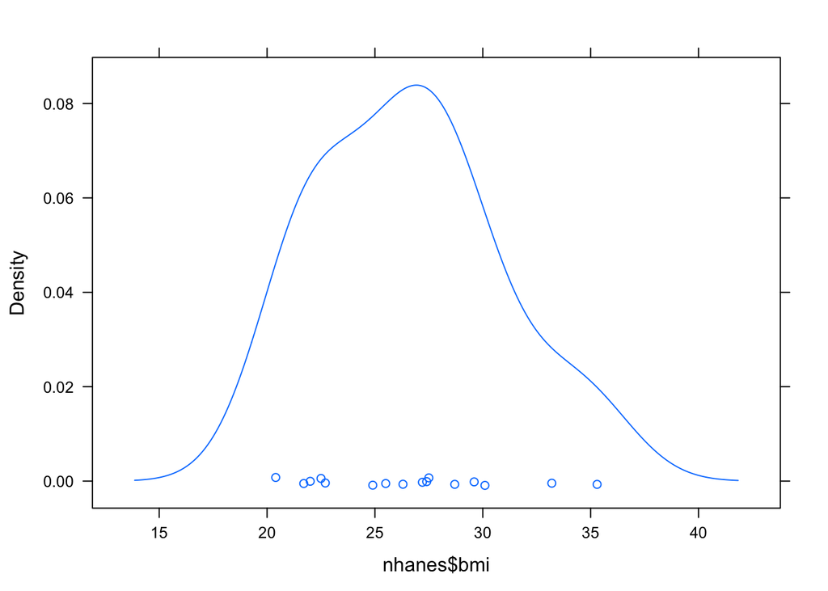

```r
densityplot(nhanes$bmi)
```

**8. Impute the missing data in the `nhanes` dataset with regression imputation.**

```r
imp <- mice(nhanes, method = "norm.predict", m = 1, maxit = 1)
```

The imputations are now done. This code imputes the missing values in the data set by the regression imputation method. The argument `method = "norm.predict"` first fits a regression model for each observed value, based on the corresponding values in other variables and then imputes the missing values with the predicted values.

**9. Again, inspect the completed data and investigate the imputed data regression model.**

```r
complete(imp)
```

```
##    age      bmi      hyp      chl
## 1    1 31.98171 1.132574 198.1082
## 2    2 22.70000 1.000000 187.0000
## 3    1 28.83478 1.000000 187.0000
## 4    3 23.21098 1.530991 228.5499
## 5    1 20.40000 1.000000 113.0000
## 6    3 21.11303 1.475446 184.0000
## 7    1 22.50000 1.000000 118.0000
## 8    1 30.10000 1.000000 187.0000
## 9    2 22.00000 1.000000 238.0000
## 10   2 31.05181 1.423268 238.5342
## 11   1 31.37488 1.123040 193.6441
## 12   2 25.06646 1.264801 194.8752
## 13   3 21.70000 1.000000 206.0000
## 14   2 28.70000 2.000000 204.0000
## 15   1 29.60000 1.000000 181.1354
## 16   1 28.64966 1.044355 173.8032
## 17   3 27.20000 2.000000 284.0000
## 18   2 26.30000 2.000000 199.0000
## 19   1 35.30000 1.000000 218.0000
## 20   3 25.50000 2.000000 242.8954
## 21   1 34.82013 1.207723 218.8124
## 22   1 33.20000 1.000000 229.0000
## 23   1 27.50000 1.000000 131.0000
## 24   3 24.90000 1.000000 244.1845
## 25   2 27.40000 1.000000 186.0000
```

The repetitive numbering is gone. We have now obtained a more natural looking set of imputations: instead of filling in the same `bmi` for all ages, we now take `age` (as well as `hyp` and `chl`) into account when imputing `bmi`.

To inspect the regression model with the imputed data, run:

```r
fit <- with(imp, lm(age ~ bmi))
summary(fit)
```

```
## # A tibble: 2 x 5
##   term        estimate std.error statistic   p.value
##   <chr>          <dbl>     <dbl>     <dbl>     <dbl>
## 1 (Intercept)    4.63     0.925       5.00 0.0000463
## 2 bmi           -0.105    0.0335     -3.14 0.00462
```

It is clear that something has changed. In fact, we extrapolated (part of) the regression model for the observed data to missing data in `bmi`. In other words; the relation (read: information) gets stronger and we’ve obtained more observations.

**10. Impute the missing data in the `nhanes` dataset with stochastic regression imputation.**

```r
imp <- mice(nhanes, method = "norm.nob", m = 1, maxit = 1)
```

The imputations are now done. This code imputes the missing values in the data set by the stochastic regression imputation method. The function does not incorporate the variability of the regression weights, so it is not ‘proper’ in the sense of Rubin (1987). For small samples, the variability of the imputed data will be underestimated.

**11. Again, inspect the completed data and investigate the imputed data regression model.**

```r
complete(imp)
```

```
##    age      bmi       hyp      chl
## 1    1 35.46313 1.1192657 208.1269
## 2    2 22.70000 1.0000000 187.0000
## 3    1 28.04489 1.0000000 187.0000
## 4    3 28.36409 1.1892939 209.5659
## 5    1 20.40000 1.0000000 113.0000
## 6    3 16.34286 0.9233658 184.0000
## 7    1 22.50000 1.0000000 118.0000
## 8    1 30.10000 1.0000000 187.0000
## 9    2 22.00000 1.0000000 238.0000
## 10   2 28.72079 1.4989875 252.2370
## 11   1 30.15465 1.3168140 162.6556
## 12   2 27.21004 1.3627723 194.0366
## 13   3 21.70000 1.0000000 206.0000
## 14   2 28.70000 2.0000000 204.0000
## 15   1 29.60000 1.0000000 209.3729
## 16   1 31.14788 1.5316578 180.7741
## 17   3 27.20000 2.0000000 284.0000
## 18   2 26.30000 2.0000000 199.0000
## 19   1 35.30000 1.0000000 218.0000
## 20   3 25.50000 2.0000000 215.6881
## 21   1 27.72316 1.9274899 167.2897
## 22   1 33.20000 1.0000000 229.0000
## 23   1 27.50000 1.0000000 131.0000
## 24   3 24.90000 1.0000000 246.9890
## 25   2 27.40000 1.0000000 186.0000
```

We have once more obtained a more natural looking set of imputations, where instead of filling in the same `bmi` for all ages, we now take `age` (as well as `hyp` and `chl`) into account when imputing `bmi`. We also add a random error to allow for our imputations to be off the regression line.

To inspect the regression model with the imputed data, run:

```r
fit <- with(imp, lm(age ~ bmi))
summary(fit)
```

```
## # A tibble: 2 x 5
##   term        estimate std.error statistic  p.value
##   <chr>          <dbl>     <dbl>     <dbl>    <dbl>
## 1 (Intercept)   4.23      0.918       4.60 0.000125
## 2 bmi          -0.0909    0.0334     -2.72 0.0122
```

**12. Re-run the stochastic imputation model with seed `123` and verify if your results are the same as the ones below**

```
## # A tibble: 2 x 5
##   term        estimate std.error statistic p.value
##   <chr>          <dbl>     <dbl>     <dbl>   <dbl>
## 1 (Intercept)   4.13      1.13        3.66 0.00129
## 2 bmi          -0.0904    0.0426     -2.12 0.0449
```

The imputation procedure uses random sampling, and therefore, the results will be (perhaps slightly) different if we repeat the imputations. In order to get exactly the same result, you can use the seed argument

```r
imp <- mice(nhanes, method = "norm.nob", m = 1, maxit = 1, seed = 123)
fit <- with(imp, lm(age ~ bmi))
summary(fit)
```

where 123 is some arbitrary number that you can choose yourself. Re-running this command will always yields the same imputed values. The ability to replicate one’s findings exactly is considered essential in today’s reproducible science.

##### Multiple imputation

**13. Let us impute the missing data in the `nhanes` dataset**

```r
imp <- mice(nhanes)
imp
```

```
## Multiply imputed data set
## Call:
## mice(data = nhanes)
## Number of multiple imputations:  5
## Missing cells per column:
## age bmi hyp chl
##   0   9   8  10
## Imputation methods:
##   age   bmi   hyp   chl
##    "" "pmm" "pmm" "pmm"
## VisitSequence:
## bmi hyp chl
##   2   3   4
## PredictorMatrix:
##     age bmi hyp chl
## age   0   0   0   0
## bmi   1   0   1   1
## hyp   1   1   0   1
## chl   1   1   1   0
## Random generator seed value:  NA
```

The imputations are now done. As you can see, the algorithm ran for 5 iterations (the default) and presented us with 5 imputations for each missing datum. For the rest of this document we will omit printing of the iteration cycle when we run `mice`. We do so by adding `print=F` to the `mice` call.

The object `imp` contains a multiply imputed data set (of class `mids`). It encapsulates all information from imputing the `nhanes` dataset, such as the original data, the imputed values, the number of missing values, number of iterations, and so on.

To obtain an overview of the information stored in the object `imp`, use the `attributes()` function:

```r
attributes(imp)
```

```
## $names
##  [1] "call"            "data"            "m"
##  [4] "nmis"            "imp"             "method"
##  [7] "predictorMatrix" "visitSequence"   "form"
## [10] "post"            "seed"            "iteration"
## [13] "lastSeedValue"   "chainMean"       "chainVar"
## [16] "loggedEvents"    "pad"
##
## $class
## [1] "mids"
```

For example, the original data are stored as

```r
imp$data
```

```
##    age  bmi hyp chl
## 1    1   NA  NA  NA
## 2    2 22.7   1 187
## 3    1   NA   1 187
## 4    3   NA  NA  NA
## 5    1 20.4   1 113
## 6    3   NA  NA 184
## 7    1 22.5   1 118
## 8    1 30.1   1 187
## 9    2 22.0   1 238
## 10   2   NA  NA  NA
## 11   1   NA  NA  NA
## 12   2   NA  NA  NA
## 13   3 21.7   1 206
## 14   2 28.7   2 204
## 15   1 29.6   1  NA
## 16   1   NA  NA  NA
## 17   3 27.2   2 284
## 18   2 26.3   2 199
## 19   1 35.3   1 218
## 20   3 25.5   2  NA
## 21   1   NA  NA  NA
## 22   1 33.2   1 229
## 23   1 27.5   1 131
## 24   3 24.9   1  NA
## 25   2 27.4   1 186
```

and the imputations are stored as

```r
imp$imp
```

```
## $age
## NULL
##
## $bmi
##       1    2    3    4    5
## 1  30.1 27.2 29.6 35.3 29.6
## 3  29.6 29.6 29.6 26.3 30.1
## 4  27.4 20.4 21.7 27.4 25.5
## 6  24.9 24.9 20.4 21.7 20.4
## 10 27.5 27.5 27.4 24.9 22.0
## 11 30.1 28.7 29.6 22.0 33.2
## 12 27.5 29.6 29.6 27.5 28.7
## 16 26.3 30.1 29.6 28.7 27.2
## 21 26.3 22.0 27.2 35.3 24.9
##
```

[output cut: 23 more lines]

**14. Extract the completed data**

By default, `mice()` calculates five (*m* = 5) imputed data sets. In order to get the third imputed data set, use the `complete()` function

```r
c3 <- complete(imp, 3)
md.pattern(c3)
```

```
##      age bmi hyp chl
## [1,]   1   1   1   1 0
## [2,]   0   0   0   0 0
```

```r
c.long <- complete(imp, "long")
c.long
```

```
##     .imp .id age  bmi hyp chl
## 1      1   1   1 30.1   1 187
## 2      1   2   2 22.7   1 187
## 3      1   3   1 29.6   1 187
## 4      1   4   3 27.4   2 184
## 5      1   5   1 20.4   1 113
## 6      1   6   3 24.9   2 184
## 7      1   7   1 22.5   1 118
## 8      1   8   1 30.1   1 187
## 9      1   9   2 22.0   1 238
## 10     1  10   2 27.5   2 218
## 11     1  11   1 30.1   1 199
## 12     1  12   2 27.5   2 186
## 13     1  13   3 21.7   1 206
## 14     1  14   2 28.7   2 204
```

[output cut: 111 more lines]

and

```r
c.broad <- complete(imp, "broad")
c.broad
```

```
##    age.1 bmi.1 hyp.1 chl.1 age.2 bmi.2 hyp.2 chl.2 age.3 bmi.3 hyp.3 chl.3
## 1      1  30.1     1   187     1  27.2     1   131     1  29.6     1   187
## 2      2  22.7     1   187     2  22.7     1   187     2  22.7     1   187
## 3      1  29.6     1   187     1  29.6     1   187     1  29.6     1   187
## 4      3  27.4     2   184     3  20.4     1   187     3  21.7     1   186
## 5      1  20.4     1   113     1  20.4     1   113     1  20.4     1   113
## 6      3  24.9     2   184     3  24.9     1   184     3  20.4     2   184
## 7      1  22.5     1   118     1  22.5     1   118     1  22.5     1   118
## 8      1  30.1     1   187     1  30.1     1   187     1  30.1     1   187
## 9      2  22.0     1   238     2  22.0     1   238     2  22.0     1   238
## 10     2  27.5     2   218     2  27.5     1   187     2  27.4     1   186
## 11     1  30.1     1   199     1  28.7     1   187     1  29.6     1   238
## 12     2  27.5     2   186     2  29.6     1   187     2  29.6     2   218
## 13     3  21.7     1   206     3  21.7     1   206     3  21.7     1   206
## 14     2  28.7     2   204     2  28.7     2   204     2  28.7     2   204
```

[output cut: 37 more lines]

are completed data sets in long and broad format, respectively. See `?complete` for more detail.

**Conclusion**

We have seen that (multiple) imputation is straightforward with `mice`. However, don’t let the simplicity of the software fool you into thinking that the problem itself is also straightforward. In the next vignette we will therefore explore how the mice package can flexibly provide us the tools to assess and control the imputation of missing data.

**References**

Rubin, D. B. *Multiple imputation for nonresponse in surveys*. John Wiley & Sons, 1987. [Amazon](http://www.amazon.com/Multiple-Imputation-Nonresponse-Surveys-Donald/dp/0471655740/ref=sr_1_1?ie=UTF8&qid=1434466788&sr=8-1&keywords=Multiple+imputation+for+nonresponse+in+surveys)

Schafer, J.L. (1997). *Analysis of Incomplete Multivariate Data*. London: Chapman & Hall. Table 6.14. [Amazon](http://www.amazon.com/Incomplete-Multivariate-Monographs-Statistics-Probability/dp/0412040611/ref=sr_1_1?ie=UTF8&qid=1434466828&sr=8-1&keywords=Analysis+of+Incomplete+Multivariate+Data)

Van Buuren, S. and Groothuis-Oudshoorn, K. (2011). mice: Multivariate Imputation by Chained Equations in R. *Journal of Statistical Software*, 45(3), 1-67. [pdf](http://www.jstatsoft.org/v45/i03/paper)

**- End of Vignette**